# Лабораторна робота №4

1. Спершу імпортуємо, візуалізуємо та аналізуємо дані

```python
import pandas as pd
import seaborn as sns
import matplotlib.pyplot as plt
import statsmodels.formula.api as smf
```

```python
df = pd.read_csv("mtcars.csv")

df.head()
```

|  | car_name | mpg | cyl | disp | hp | drat | wt | qsec | vs | am | gear | carb |
| --- | --- | --- | --- | --- | --- | --- | --- | --- | --- | --- | --- | --- |
| 0 | Mazda RX4 | 21.0 | 6 | 160.0 | 110 | 3.90 | 2.620 | 16.46 | 0 | 1 | 4 | 4 |
| 1 | Mazda RX4 Wag | 21.0 | 6 | 160.0 | 110 | 3.90 | 2.875 | 17.02 | 0 | 1 | 4 | 4 |
| 2 | Datsun 710 | 22.8 | 4 | 108.0 | 93 | 3.85 | 2.320 | 18.61 | 1 | 1 | 4 | 1 |
| 3 | Hornet 4 Drive | 21.4 | 6 | 258.0 | 110 | 3.08 | 3.215 | 19.44 | 1 | 0 | 3 | 1 |
| 4 | Hornet Sportabout | 18.7 | 8 | 360.0 | 175 | 3.15 | 3.440 | 17.02 | 0 | 0 | 3 | 2 |

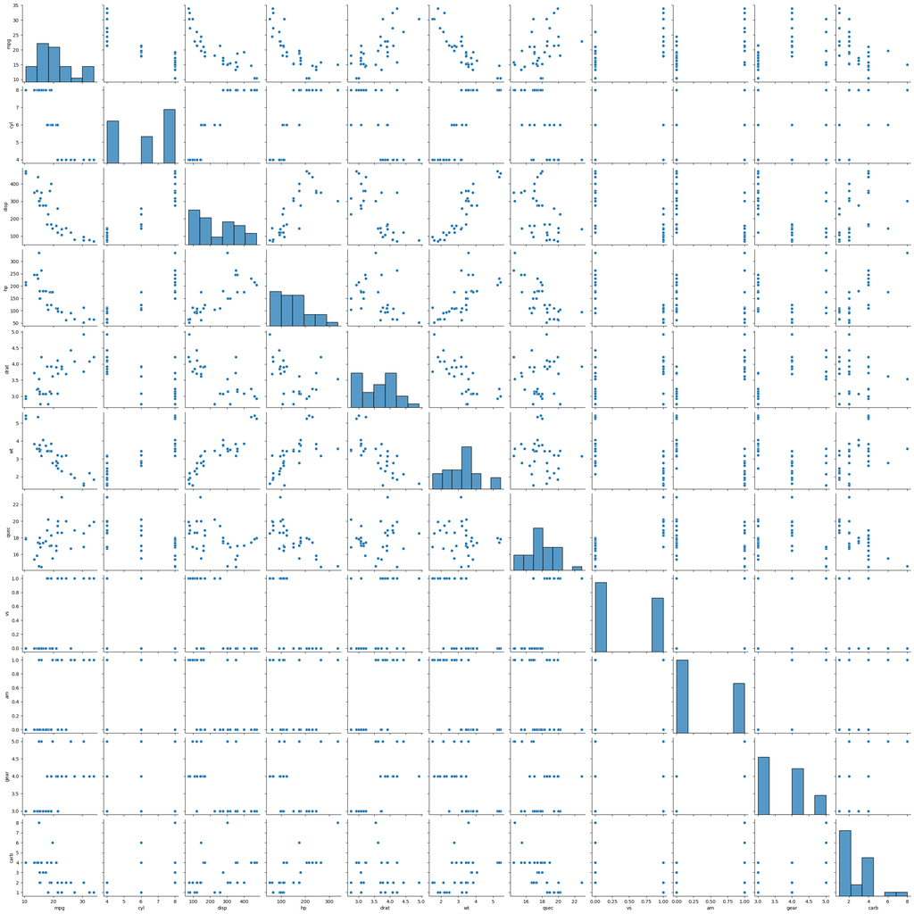

```python
sns.pairplot(df)
```

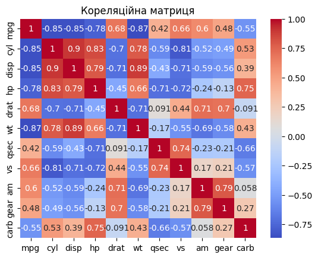

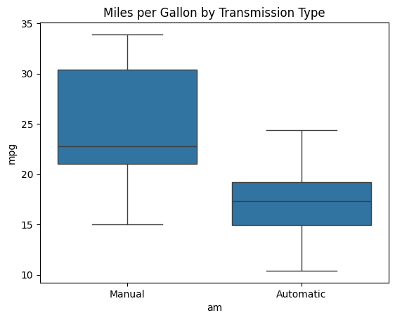

```python
df.drop(df.columns[0], axis=1, inplace=True)

corr_matrix = df.corr()
sns.heatmap(corr_matrix, annot=True, cmap='coolwarm')
plt.title('Кореляційна матриця')
plt.show()

df['am'] = df['am'].map({0: 'Automatic', 1: 'Manual'})

sns.boxplot(x='am', y='mpg', data=df)
plt.title("Miles per Gallon by Transmission Type")
plt.show()
```

Вже зараз, проаналізувавши box plot вище можемо сказати, `ручна (manual) коробка передач краща за автоматичну` так як для неї, вищий медіанний показник, діапазон значень та верхня межа, що свідчить про вищі значення mpg а отже і менші витрати пального. Проте щоб впевнитись в цьому і визначити різницю в милях на галон між автоматичною і ручною коробками передач використаємо регресійні моделі

2. Регресійні моделі

На цьому кроці використаємо дві моделі:

- OLS з однією незалежною змінною (am)
- OLS з кількома незалежними змінними: wt, qsec та am. Такий вибір грунтується на інформації про датасет (були обрані ті параметри, що логічно можуть впливати на mpg) а також значеннях отриманих з кореляційної матриці.

```python
model1 = smf.ols('mpg ~ C(am)', data=df).fit()
print(model1.summary())

coef_diff = model1.params[1]
conf_int = model1.conf_int().loc['C(am)[T.Manual]']
print(f"Estimated MPG difference between Manual and Automatic: {coef_diff:.2f} MPG")
print(f"95% CI: ({conf_int[0]:.2f}, {conf_int[1]:.2f})")
```

```
                            OLS Regression Results
==============================================================================
Dep. Variable:                    mpg   R-squared:                       0.360
Model:                            OLS   Adj. R-squared:                  0.338
Method:                 Least Squares   F-statistic:                     16.86
Date:                Sun, 02 Mar 2025   Prob (F-statistic):           0.000285
Time:                        23:55:34   Log-Likelihood:                -95.242
No. Observations:                  32   AIC:                             194.5
Df Residuals:                      30   BIC:                             197.4
Df Model:                           1
Covariance Type:            nonrobust
===================================================================================
                      coef    std err          t      P>|t|      [0.025      0.975]
-----------------------------------------------------------------------------------
Intercept          17.1474      1.125     15.247      0.000      14.851      19.444
C(am)[T.Manual]     7.2449      1.764      4.106      0.000       3.642      10.848
==============================================================================
Omnibus:                        0.480   Durbin-Watson:                   1.065
Prob(Omnibus):                  0.787   Jarque-Bera (JB):                0.589
Skew:                           0.051   Prob(JB):                        0.745
Kurtosis:                       2.343   Cond. No.                         2.46
==============================================================================

Notes:
[1] Standard Errors assume that the covariance matrix of the errors is correctly specified.
Estimated MPG difference between Manual and Automatic: 7.24 MPG
95% CI: (3.64, 10.85)
```

```
                            OLS Regression Results
==============================================================================
Dep. Variable:                    mpg   R-squared:                       0.850
Model:                            OLS   Adj. R-squared:                  0.834
Method:                 Least Squares   F-statistic:                     52.75
Date:                Sun, 02 Mar 2025   Prob (F-statistic):           1.21e-11
Time:                        23:55:34   Log-Likelihood:                -72.060
No. Observations:                  32   AIC:                             152.1
Df Residuals:                      28   BIC:                             158.0
Df Model:                           3
Covariance Type:            nonrobust
================================================================================
                   coef    std err          t      P>|t|      [0.025      0.975]
--------------------------------------------------------------------------------
Intercept        9.6178      6.960      1.382      0.178      -4.638      23.874
am[T.Manual]     2.9358      1.411      2.081      0.047       0.046       5.826
wt              -3.9165      0.711     -5.507      0.000      -5.373      -2.460
qsec             1.2259      0.289      4.247      0.000       0.635       1.817
==============================================================================
Omnibus:                        2.574   Durbin-Watson:                   1.714
Prob(Omnibus):                  0.276   Jarque-Bera (JB):                2.213
Skew:                           0.540   Prob(JB):                        0.331
Kurtosis:                       2.297   Cond. No.                         296.
==============================================================================

Notes:
[1] Standard Errors assume that the covariance matrix of the errors is correctly specified.
Estimated MPG difference between Manual and Automatic: 2.94 MPG
95% CI: (0.05, 5.83)
```

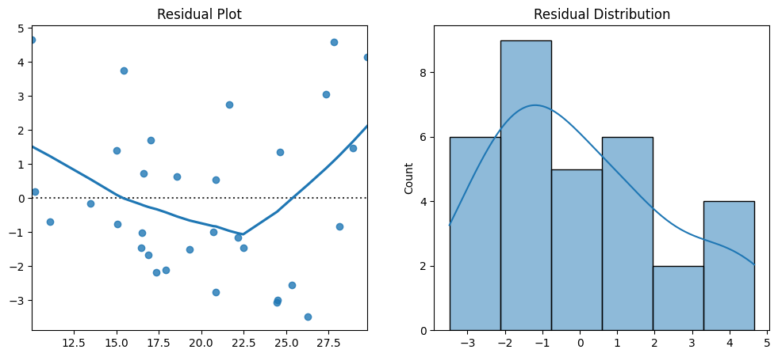

```python
model2 = smf.ols('mpg ~ wt + qsec + am', data=df).fit()
print(model2.summary())

coef_diff = model2.params[1]
conf_int = model2.conf_int().loc['am[T.Manual]']
print(f"Estimated MPG difference between Manual and Automatic: {coef_diff:.2f} MPG")
print(f"95% CI: ({conf_int[0]:.2f}, {conf_int[1]:.2f})")

fig, axs = plt.subplots(1, 2, figsize=(12, 5))
sns.residplot(x=model2.fittedvalues, y=model2.resid, lowess=True, ax=axs[0])
axs[0].set_title("Residual Plot")
sns.histplot(model2.resid, kde=True, ax=axs[1])
axs[1].set_title("Residual Distribution")
plt.show()
```

Проаналізувавши результати отримані від двох цих моделей можемо відповісти на поставлені питання.

**Автоматична чи ручна коробка передач краща для миль на галон?**

**Визначте різницю в милях на галон між автоматичною і ручною коробками передач.**

- За результатами першої (спрощеної) моделі, автомобілі з `механічною трансмісією` мають вищу економію палива, ніж з автоматичною так як значення *mpg = 17.1474 + am*7.2449* вище при am = 1. Різниця в mpg між механічною і автоматичною трансмісією відповідно становить `7.2449 mpg` (95% CI: 3.64, 10.85).
- За результатами другої (розширеної) моделі, після врахування впливу ваги автомобіля (wt) і часу розгону (qsec), різниця між трансмісіями зменшується до `2.94 mpg` (95% CI: 0.05, 5.83). Хоча різниця зменшилась, `механічна` трансмісія все ще показує трохи кращі результати, але вплив став менш вираженим через вплив додаткових факторів.

**Яка ж модель є кращою?**

- У першій моделі p-значення для am = 0.000, що означає, що різниця між механічною та автоматичною трансмісією є значущою. У другій моделі p-значення для am = 0.047, що також вказує на значущість, але ефект став меншим після додавання змінних wt і qsec. Це означає, що частина впливу трансмісії на mpg пояснюється вагою автомобіля та часом розгону.
- r^2 показує, яку частку варіації mpg пояснює модель. У першій моделі r^2 = 0.360, тобто лише 36% змін у витраті пального пояснюються трансмісією. У другій моделі r^2 = 0.850, що свідчить про значно кращу пояснювальну здатність після додавання wt і qsec.
- AIC оцінює якість моделі, при цьому менше значення означає кращу модель. Перша модель має aic = 194.5, тоді як у другої aic = 152.1, що вказує на її перевагу.

Загалом порівняння моделей показує, що друга модель є кращою, оскільки вона має значно вище r^2, нижчий aic і враховує додаткові значущі змінні. це означає, що різниця в споживанні пального між механічною та автоматичною трансмісією існує, але значною мірою пояснюється іншими факторами, такими як вага автомобіля та динамічні характеристики.

Таким чином, `механічна коробка передач` є кращою за результатами обох моделей, відповідно ж до кращої (розширеної) другої моделі різницю в милях на галон між автоматичною і ручною коробками передач становить `2.94 mpg`.

3. Також додатково використаємо логістичну регресію, змінивши місцями залежну і незалежну змінні.

```python
df['am'] = df['am'].map({'Automatic': 0, 'Manual': 1})

logit_model = smf.logit('am ~ mpg', data=df).fit()

print(logit_model.summary())
```

```
Optimization terminated successfully.
         Current function value: 0.463674
         Iterations 6
                           Logit Regression Results
==============================================================================
Dep. Variable:                     am   No. Observations:                   32
Model:                          Logit   Df Residuals:                       30
Method:                           MLE   Df Model:                            1
Date:                Sun, 02 Mar 2025   Pseudo R-squ.:                  0.3135
Time:                        23:55:34   Log-Likelihood:                -14.838
converged:                       True   LL-Null:                       -21.615
Covariance Type:            nonrobust   LLR p-value:                 0.0002317
==============================================================================
                 coef    std err          z      P>|z|      [0.025      0.975]
------------------------------------------------------------------------------
Intercept     -6.6035      2.351     -2.808      0.005     -11.212      -1.995
mpg            0.3070      0.115      2.673      0.008       0.082       0.532
==============================================================================
```

Як бачимо, для логістичної регресії обидва параметри `Intercept` та `mpg` є статистично значущими ((P>|z|) < 0.05 в обох випадках). Значення параметру mpg = 0.307 означає, що з кожним збільшенням mpg на 1 одиницю ймовірність вибору механічної коробки передач зростає. Обчисливши додатково odds ratio як `exp(0.307) = 1.36` визначимо, що збільшення mpg на 1 одиницю підвищує шанси вибору механічної трансмісії на 36%. Довірчий інтервал для цього параметру складає [0.082, 0.532]. Таким чином, можемо зробити висновок, що `автомобілі з вищим mpg з більшою ймовірністю мають механічну трансмісію`, що цілком збігається з результатами отриманими від попередніх моделей.